# StockResearch

Gabriel Foix

2020-12-01

Buy Quality at the a good momentum and get rid of the fishy stocks on time. That’s all.

### Factor 1: Quality

1. Healthy debts: A company shoud generate cash in order to repay its debt. The **Free Cash Flow to Debt** ratio is a good indicator of how quick a company pays back its debt. The lower this ratio the better.

FCF2D = $\frac{Debt}{Free Cash Flow}$

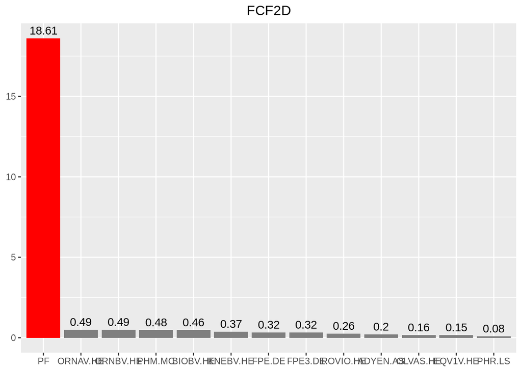

2. Profitability: ROA

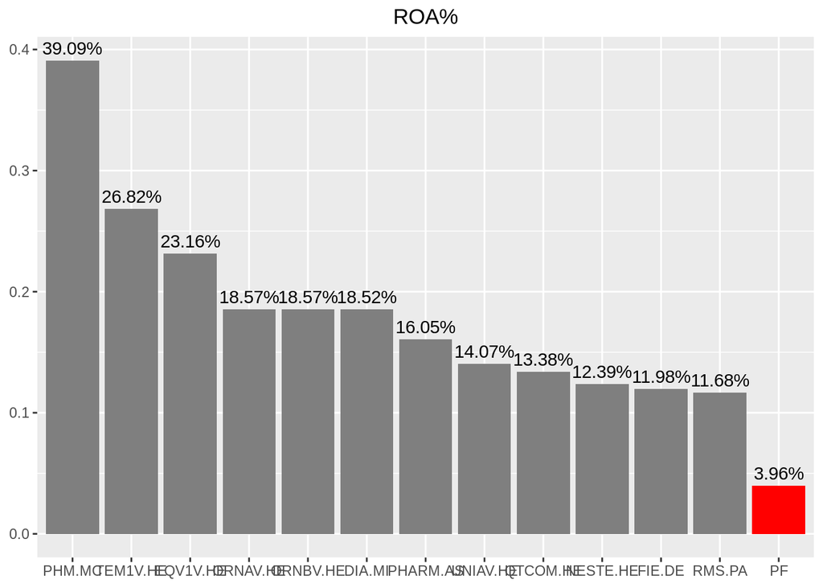

3. High Margin: We look for companies that generate free cash flow compare to its price. The **Free Cash Flow to Entreprise Value** ratio tells us how many years of cash flow would be needed to the return the 100% of the investment. Again, the lower, the better. Values bellow 1 would mean “free lunch”.

FCF2EV = $\frac{EV}{Free Cash Flow}$

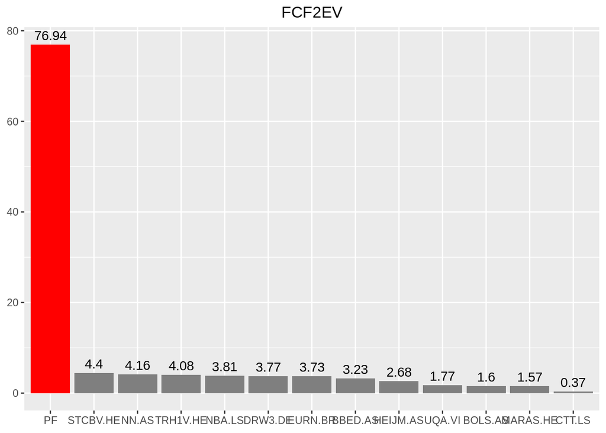

### Factor 2: Momentum

Don’t hold onto a stock simply because it is high quality. So called quality stocks have cycles too. Stan Weinstein (page 177)

Generic Intermediate-Term Momentum Based on Gray-Vogel (page 80)

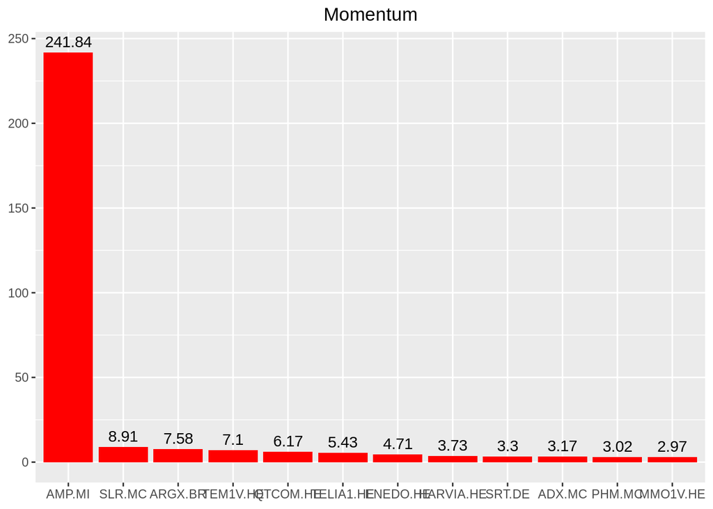

### Factor 3: Timing Signal

Sell Signal - Pr < 1% SMA 30 weeks and slope negative (< -0.2)  
Buy Signal - 109% * SMA30 < Pr > SMA 30 and slope positive (> 0.2)  
Hold Signal - Neither Buy nor Sell

### Summary

Summary

| Ticker | Signal | Quality | Momentum | Final_rank |
| --- | --- | --- | --- | --- |
| QTCOM.HE | HOLD | 491.0 | 489 | 493.0 |
| DIA.MI | HOLD | 493.0 | 473 | 492.0 |
| SLR.MC | HOLD | 466.0 | 492 | 491.0 |
| ADX.MC | HOLD | 469.0 | 484 | 490.0 |
| TELIA1.HE | HOLD | 460.5 | 488 | 489.0 |
| ROVI.MC | HOLD | 486.0 | 449 | 488.0 |
| YEINT.HE | HOLD | 472.0 | 461 | 487.0 |
| DSM.AS | BUY | 474.0 | 447 | 486.0 |
| PUM.DE | HOLD | 464.0 | 456 | 485.0 |
| PHM.MC | HOLD | 424.5 | 483 | 484.0 |
| TEG.DE | BUY | 456.0 | 451 | 483.0 |
| EDP.LS | HOLD | 465.0 | 441 | 482.0 |
| VNA.DE | HOLD | 477.0 | 427 | 481.0 |
| IBE.MC | BUY | 467.0 | 436 | 480.0 |
| CLNX.MC | HOLD | 411.0 | 479 | 479.0 |
| EDPR.LS | HOLD | 420.0 | 469 | 478.0 |
| ENEL.MI | BUY | 476.0 | 409 | 477.0 |
| ACG1V.HE | HOLD | 431.0 | 452 | 476.0 |
| DIGIA.HE | BUY | 399.0 | 478 | 475.0 |
| REC.MI | HOLD | 489.0 | 377 | 474.0 |
| EVLI.HE | HOLD | 449.5 | 411 | 473.0 |
| GXI.DE | BUY | 470.0 | 388 | 472.0 |
| UNIAV.HE | BUY | 492.0 | 362 | 471.0 |
| FBK.MI | BUY | 434.0 | 418 | 470.0 |
| SHL.DE | HOLD | 481.0 | 368 | 469.0 |
| ORDI.AS | HOLD | 410.0 | 437 | 468.0 |
| VIS.MC | HOLD | 488.0 | 355 | 467.0 |
| ANA.MC | HOLD | 441.0 | 398 | 466.0 |
| COFB.BR | HOLD | 462.0 | 374 | 465.0 |
| ALO.PA | HOLD | 452.0 | 380 | 464.0 |

[output cut: 463 more lines]